# Отчет по лабораторной работе №4

Работа с репозиториями Git

Спелов А. Н.

Российский университет дружбы народов, Москва, Россия

23 февраля 2024

# Информация

## Докладчик

- Спелов Андрей Николаевич
- НПИбд-02-23 Студ. билет:
- Российский университет дружбы народов
- 1132231839@pfur.ru

# Вводная часть

## Цели и задачи

- Получить навыки правильной работы с репозиториями git.

# Выполнение лабораторной работы

## Скачиваем нужный софт

- Подключаем corp репозиторий

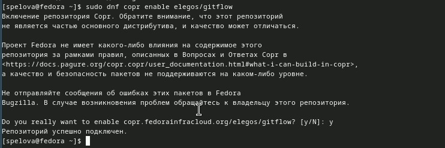

## Скачиваем нужный софт

- Скачиваем пакет gitflow

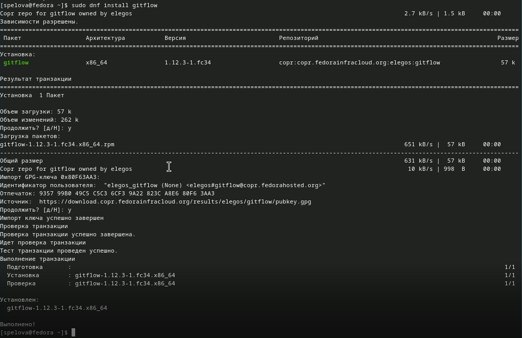

## Скачиваем нужный софт

- Скачиваем пакет nodejs

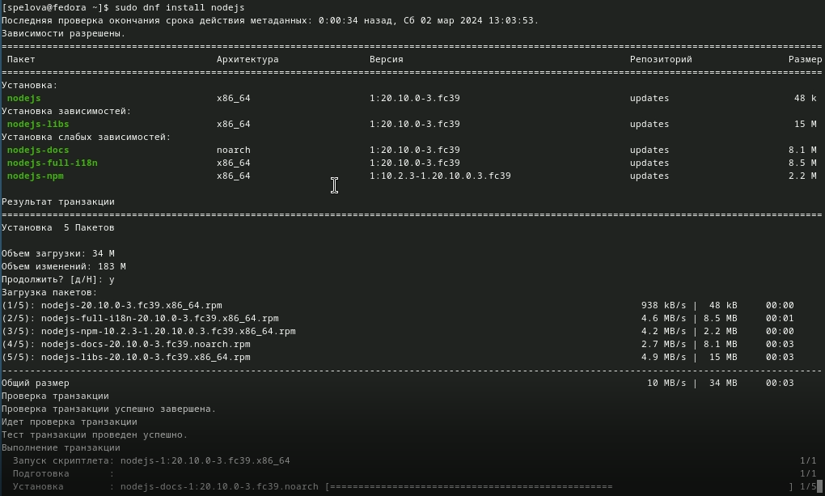

## Скачиваем нужный софт

- Скачиваем пакет pnpm

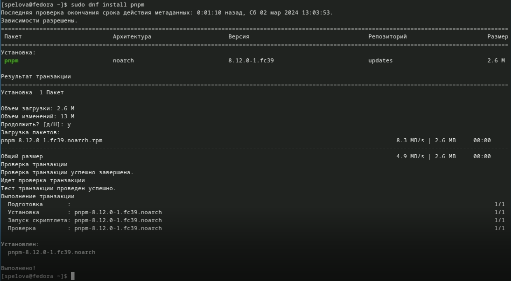

## Скачиваем нужный софт

- Запускаем pnpm

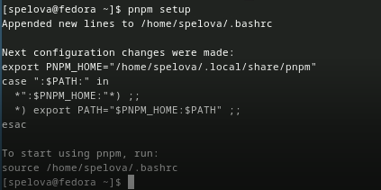

## Скачиваем нужный софт

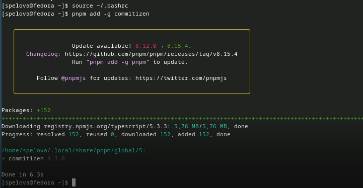

## Скачиваем нужный софт

- Вводим комманду для помощи создании логов

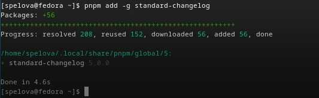

## Создание репозитория

- Создаем новый репозиторий git-extended

[figure not shown]

## Работа с репозиторием

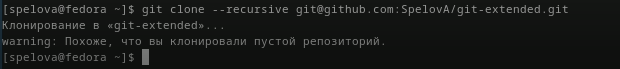

## Работа с репозиторием

- Делаем первый коммит и выкладываем на github

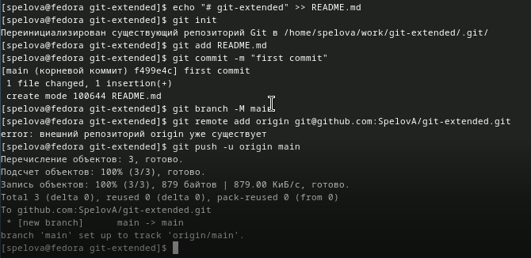

## Работа с репозиторием

- Конфигурация для пакетов Node.js

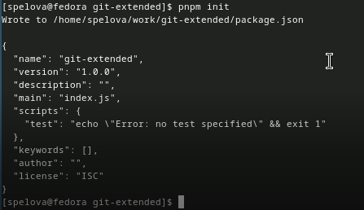

## Работа с репозиторием

- Меняем package.json в mc

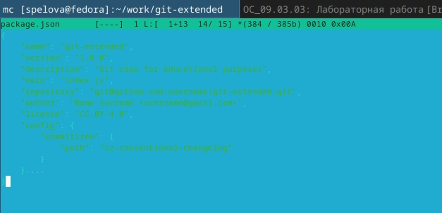

## Работа с репозиторием

- Добавляем новые файлы и отправляем на github

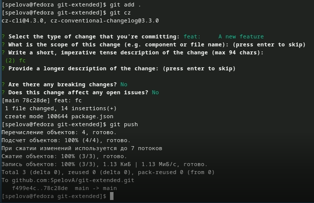

## Работа с репозиторием

- Инициализируем git-flow

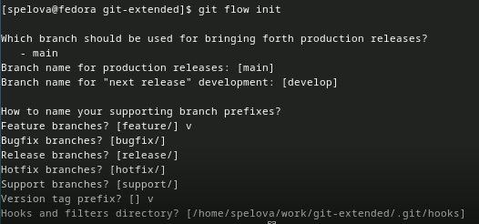

## Работа с репозиторием

- Проверяем, что мы на ветке develop

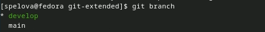

## Работа с репозиторием

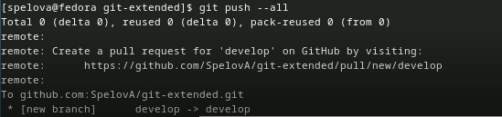

## Работа с репозиторием

- Создадим релиз с версией 1.0.0

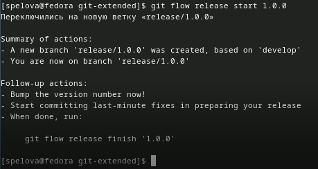

## Работа с репозиторием

- Создадим журнал изменений

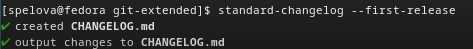

## Работа с репозиторием

- Добавим журнал изменений в индекс

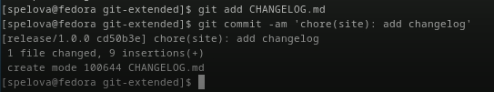

## Работа с репозиторием

- Зальём релизную ветку в основную ветку

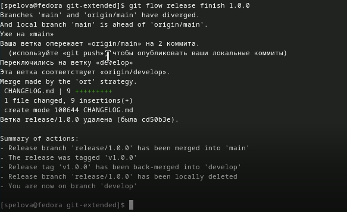

## Работа с репозиторием

- Отправим данные на github

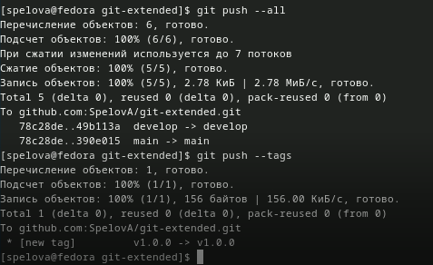

## Работа с репозиторием

- Создадим релиз на github

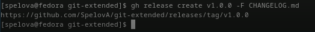

## Работа с репозиторием

- Создадим ветку для новой функциональности

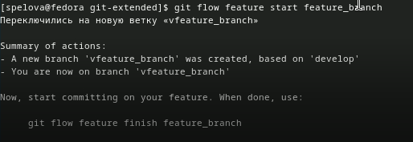

## Работа с репозиторием

- Объединяем ветки

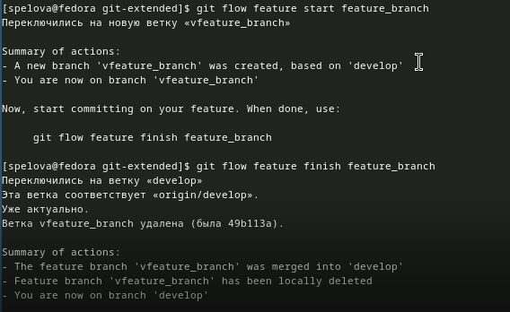

## Работа с репозиторием

- Создадим релиз с версией 1.2.3

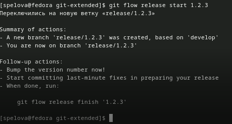

## Работа с репозиторием

- Меняем package.json в mc

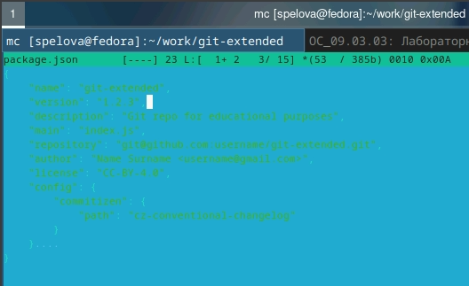

## Работа с репозиторием

- Cоздадим журнал изменений

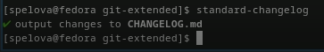

## Работа с репозиторием

- Добавим журнал изменений в индекс

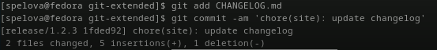

## Работа с репозиторием

- Зальём релизную ветку в основную ветку

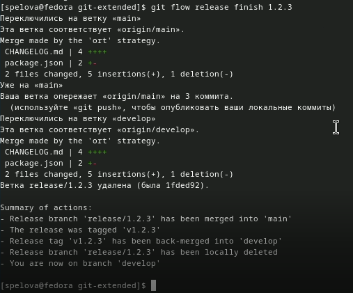

## Работа с репозиторием

- Отправим данные на github

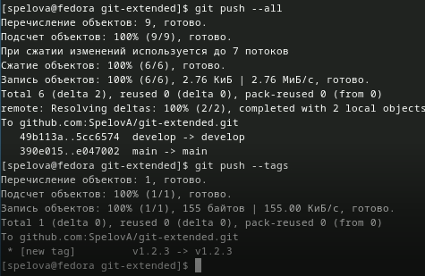

## Работа с репозиторием

- Создадим релиз на github с комментарием из журнала изменений

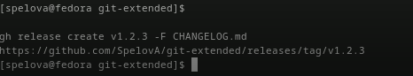

# Вывод

- Мы изучили идеологию и применение средств контроля версий и освоили умения по работе с git.